# Sampling Distribution, Central Limit Theorem, and Bootstrapping

## Exercise 10: Impact of sample size (part I)

The sample model lines become less and less variable from sample to sample.

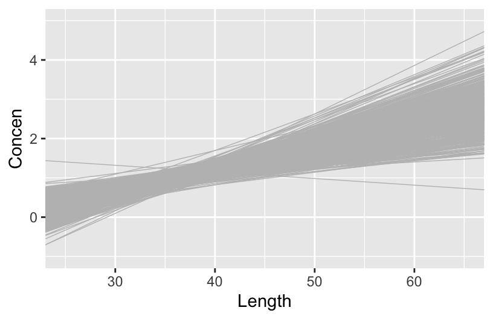

```r
# 500 sample models using samples of size 20
fish %>%
  ggplot(aes(x = Length, y = Concen)) +
  geom_smooth(method = "lm", se = FALSE) +
  geom_abline(data = sample_models_20,
              aes(intercept = `(Intercept)`, slope = Length),
              color = "gray", size = 0.25) +
  lims(x = c(25, 65), y = c(-1, 5))
```

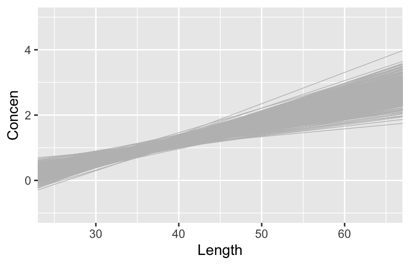

```r
# 500 sample models using samples of size 50
fish %>%
  ggplot(aes(x = Length, y = Concen)) +
  geom_smooth(method = "lm", se = FALSE) +
  geom_abline(data = sample_models_50,
              aes(intercept = `(Intercept)`, slope = Length),
              color = "gray", size = 0.25) +
  lims(x = c(25, 65), y = c(-1, 5))
```

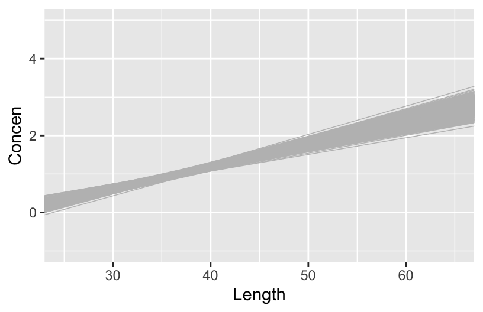

```r
# 500 sample models using samples of size 171
fish %>%
  ggplot(aes(x = Length, y = Concen)) +
  geom_smooth(method = "lm", se = FALSE) +
  geom_abline(data = sample_models_boot,
              aes(intercept = `(Intercept)`, slope = Length),
              color = "gray", size = 0.25) +
  lims(x = c(25, 65), y = c(-1, 5))
```

## Exercise 11: Impact of sample size (part II)

No matter the sample size, the sample estimates are normally distributed around the same value (here the sample slope since we’re sampling from the sample). But as sample size increases, the variability of the sample estimates decreases.

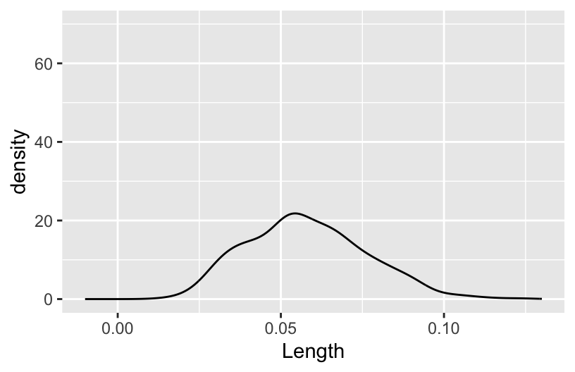

```r
# 500 sample slopes using samples of size 20
sample_models_20 %>%
  ggplot(aes(x = Length)) +
  geom_density() +
  lims(x = c(-0.01, 0.13), y = c(0, 70))
```

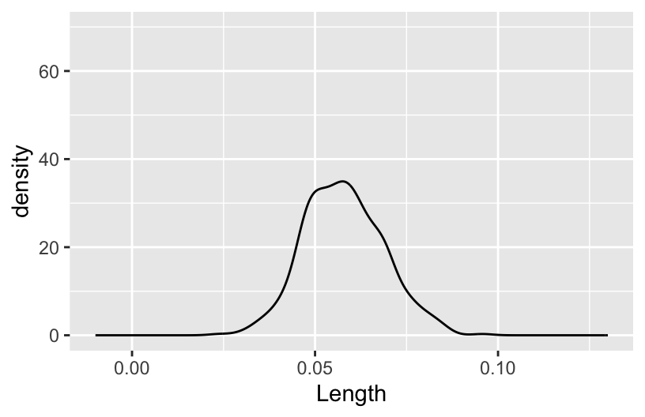

```r
# 500 sample slopes using samples of size 50
sample_models_50 %>%
  ggplot(aes(x = Length)) +
  geom_density() +
  lims(x = c(-0.01, 0.13), y = c(0, 70))
```

```r
# 500 sample slopes using samples of size 171
sample_models_171 %>%
  ggplot(aes(x = Length)) +
  geom_density() +
  lims(x = c(-0.01, 0.13), y = c(0, 70))
## Error: object 'sample_models_171' not found
```

[output not shown]

[output not shown]

## Exercise 12: Properties of sampling distributions

In light of your observations, complete the following statements about the sampling distribution of the sample slope.

1. For all sample sizes, the shape of the sampling distribution is roughly **normal** and the sampling distribution is roughly centered around **0.05813**, the sample estimate from our original data.
2. As sample size increases:  
   The average sample slope estimate IS FAIRLY STABLE.  
   The standard error of the sample slopes DECREASES.
3. Thus, as sample size increases, our sample slopes become MORE RELIABLE.